# Time series analysis

Author

Daniel F

# Análisis de series de tiempo

1. Ejemplo una serie de tiempo de pasajeros.
2. Ejemplo calentamiento global
3. Ejemplo datos de avistamientos de tiburones en buceo

```r
#Cargar librerias
library(pacman)
p_load(xts)
p_load(aTSA)
p_load(ggplot2)
p_load(fable)
p_load(fpp2)
p_load(forecast)
p_load(tsibble)
p_load(tseries)
p_load(tsbox)
p_load(plyr)
p_load(reshape)
p_load(RCurl)
```

## Ejemplo 1: Serie de tiempo de pasajeros

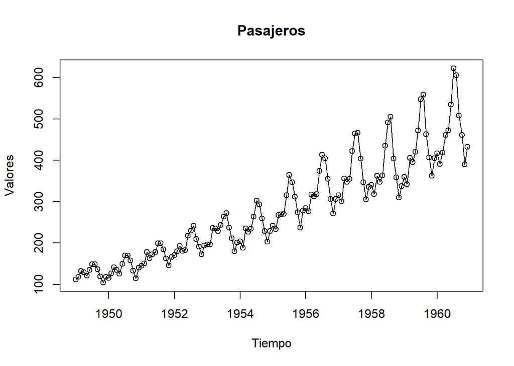

```r
#cargar datos

data("AirPassengers")
#Primero se deben graficar los datos para ver posibles patrones
plot(AirPassengers, type="o", xlab="Tiempo", ylab="Valores", main="Pasajeros")
```

Graficar la autocorrelación

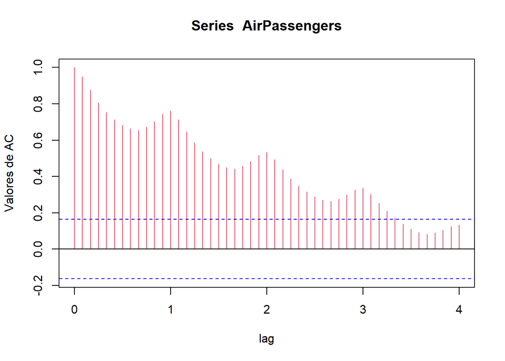

```r
acf(AirPassengers, lag=48, col = 2, xlab = "lag", ylab ="Valores de AC")
```

Autcorrelación parcial

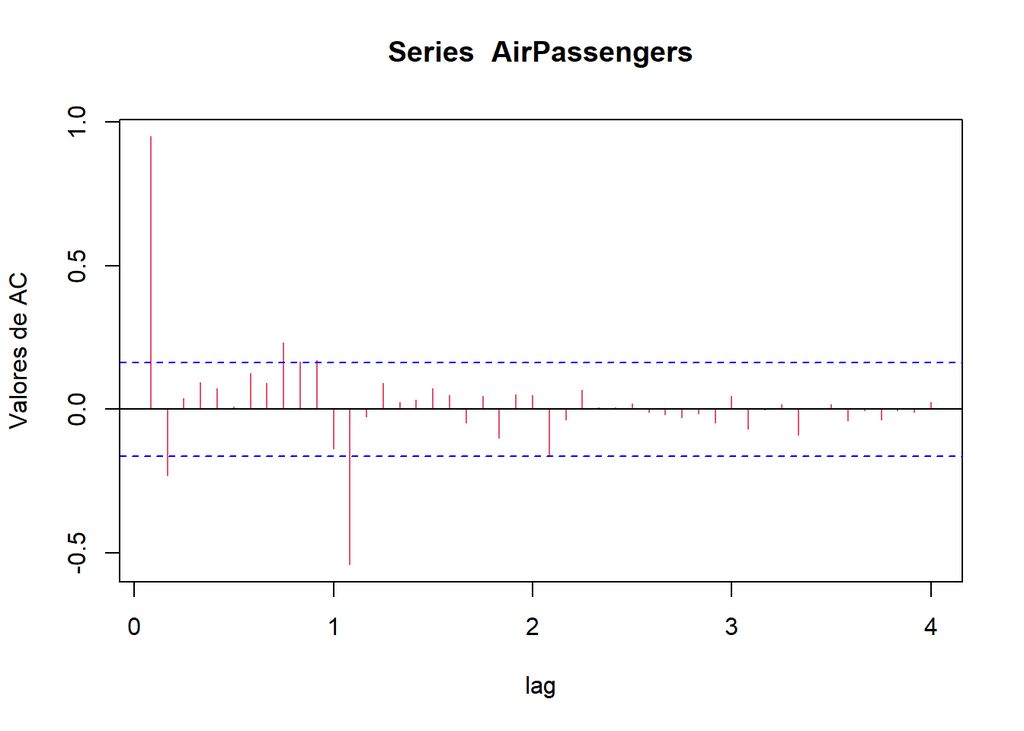

```r
pacf(AirPassengers, lag=48, col = 2, xlab = "lag", ylab ="Valores de AC")
```

Como hay confirmación de tendencia se hace la diferencia (1 - lag)

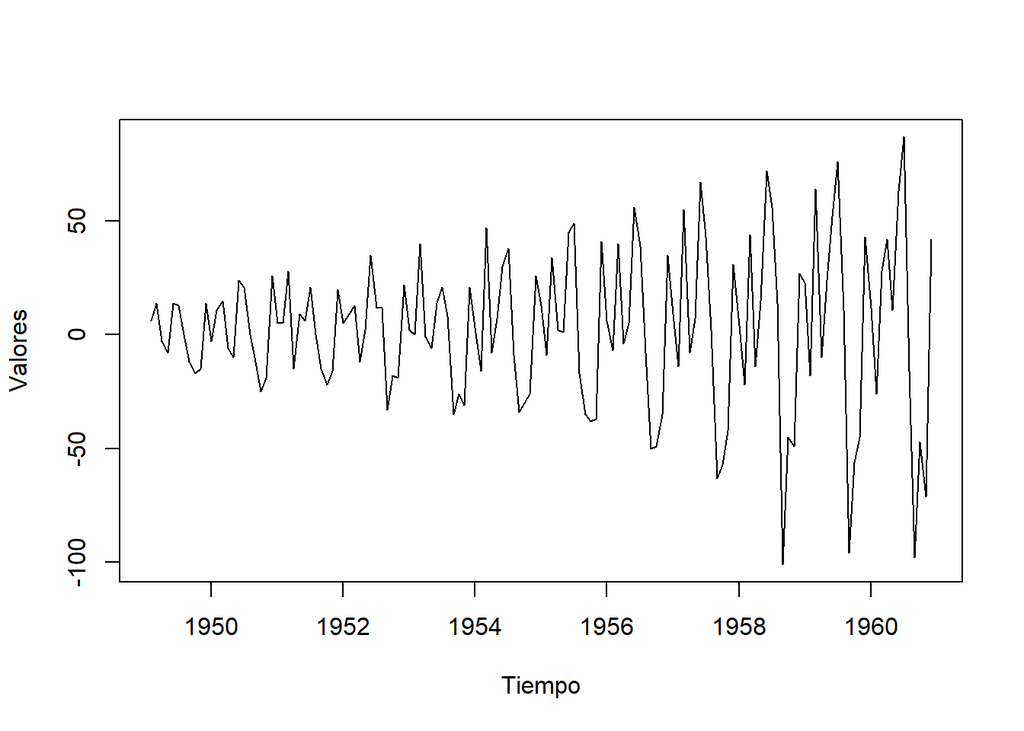

```r
plot(diff(AirPassengers), xlab="Tiempo", ylab="Valores")
```

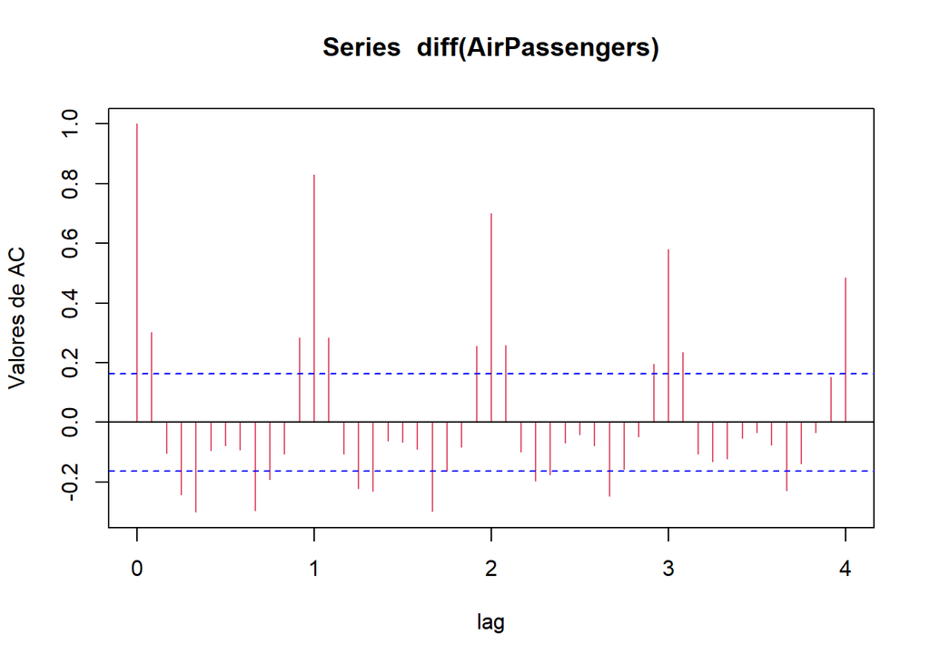

```r
acf(diff(AirPassengers), lag=48, col = 2, xlab = "lag", ylab ="Valores de AC")
```

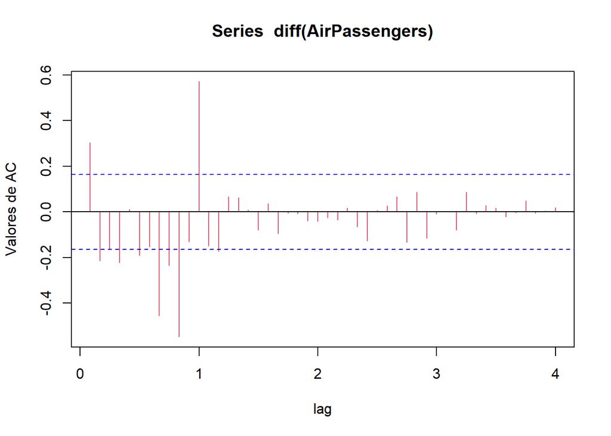

```r
pacf(diff(AirPassengers), lag=48, col = 2, xlab = "lag", ylab ="Valores de AC")
```

Como la varianza va incremento en el tiempo se debe trasformar con logaritmos para buscar la homogeneidad de las varianzas

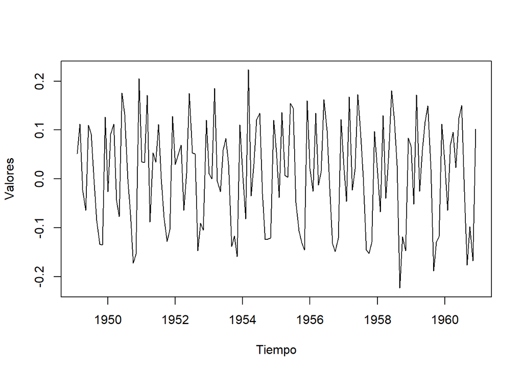

```r
plot(diff(log(AirPassengers)), xlab="Tiempo", ylab="Valores")
```

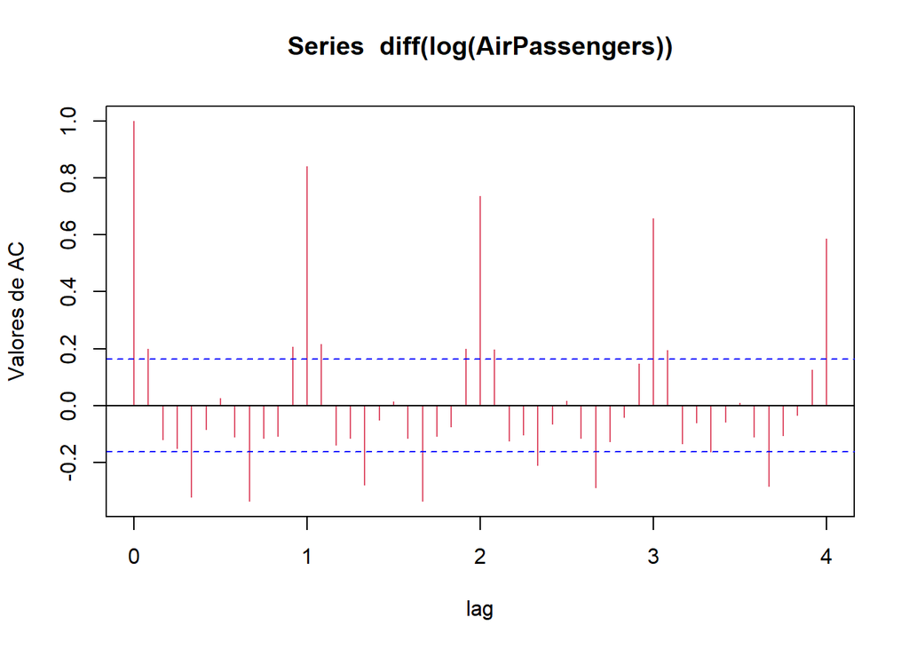

```r
acf(diff(log(AirPassengers)), lag=48, col = 2, xlab = "lag", ylab ="Valores de AC")
```

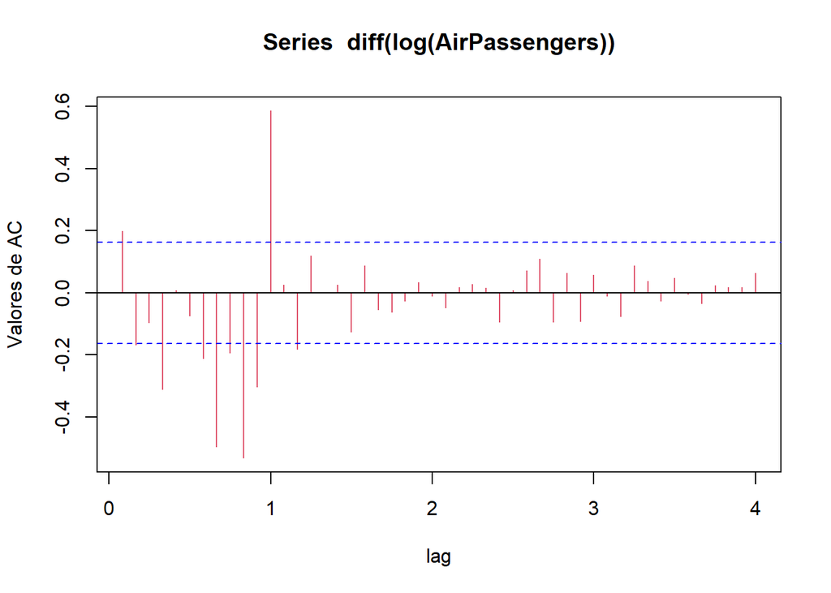

```r
pacf(diff(log(AirPassengers)), lag=48, col = 2, xlab = "lag", ylab ="Valores de AC")
```

Augmented Dickey-Fuller test para ver no estacionaridad

Devuelve la probabilidad de ser no estacionaria

- Si es mayor que 0.05 la serie es no estacionaria (tiene tendencia)
- Si es menor que 0.05 es estacionaria (No hay tendencia)

```r
adf.test(diff(log(AirPassengers)), alternative="stationary")
```

```
    Augmented Dickey-Fuller Test

data:  diff(log(AirPassengers))
Dickey-Fuller = -6.4313, Lag order = 5, p-value = 0.01
alternative hypothesis: stationary
```

Ajuste automatico de los coeficientes

```r
ARIMAmodel <- auto.arima(log(AirPassengers))
ARIMAmodel
```

```
Series: log(AirPassengers)
ARIMA(0,1,1)(0,1,1)[12]

Coefficients:
          ma1     sma1
      -0.4018  -0.5569
s.e.   0.0896   0.0731

sigma^2 = 0.001371:  log likelihood = 244.7
AIC=-483.4   AICc=-483.21   BIC=-474.77
```

[figure not shown]

(p,d,q) parte regular

(P, D, Q) parte estacional

### Diagnóstico del modelo

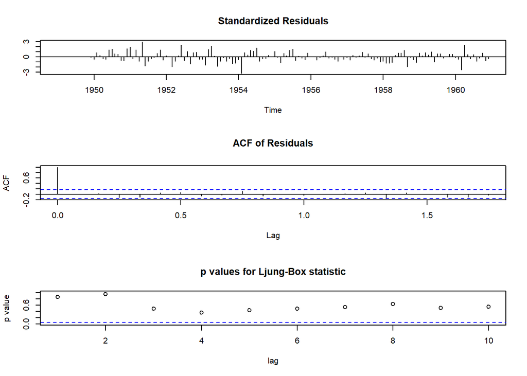

```r
# Método 1

tsdiag(ARIMAmodel) # Demuestra que el modelo no presenta autocorrelación entre residuos
```

```r
Box.test(ARIMAmodel$residuals, lag = 10, type = "Ljung-Box") # = ruido blanco
```

```
    Box-Ljung test

data:  ARIMAmodel$residuals
X-squared = 8.8097, df = 10, p-value = 0.5503
```

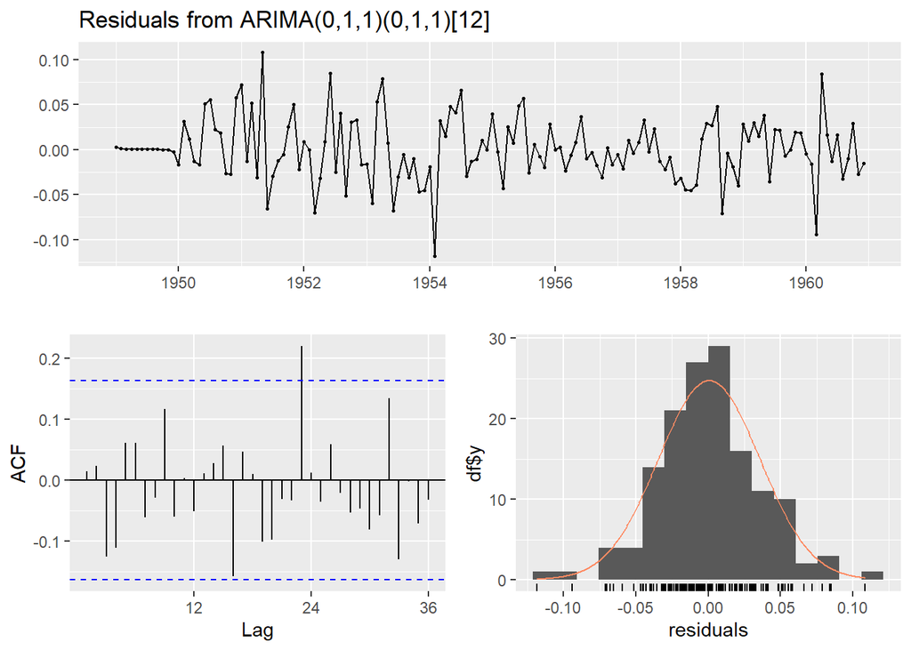

```
    Ljung-Box test

data:  Residuals from ARIMA(0,1,1)(0,1,1)[12]
Q* = 26.446, df = 22, p-value = 0.233

Model df: 2.   Total lags used: 24
```

```r
# Método 2
checkresiduals(ARIMAmodel) # modelo con solo ruido blanco = adecuado para predicciones
```

### Observados vs esperados del modelo

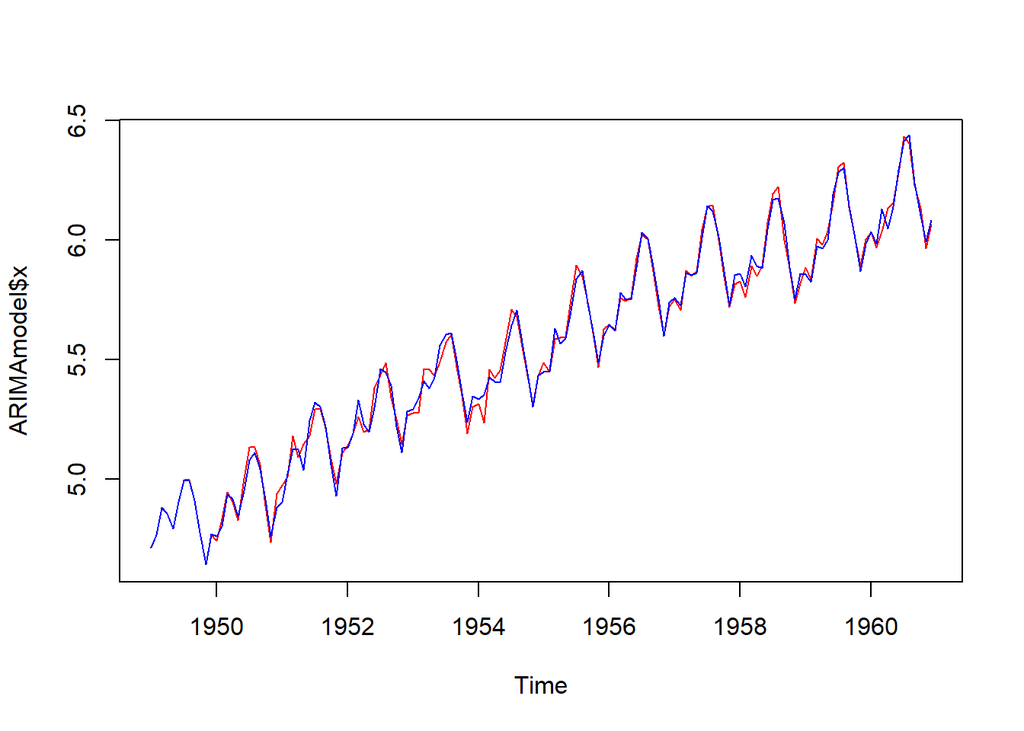

```r
plot(ARIMAmodel$x, col="red")
lines(fitted(ARIMAmodel), col="blue")
```

```r
ARIMAmodeldlog <- auto.arima(diff(log(AirPassengers)))
ARIMAmodeldlog
```

```
Series: diff(log(AirPassengers))
ARIMA(0,0,1)(0,1,1)[12]

Coefficients:
          ma1     sma1
      -0.4018  -0.5569
s.e.   0.0896   0.0731

sigma^2 = 0.001369:  log likelihood = 244.7
AIC=-483.39   AICc=-483.2   BIC=-474.77
```

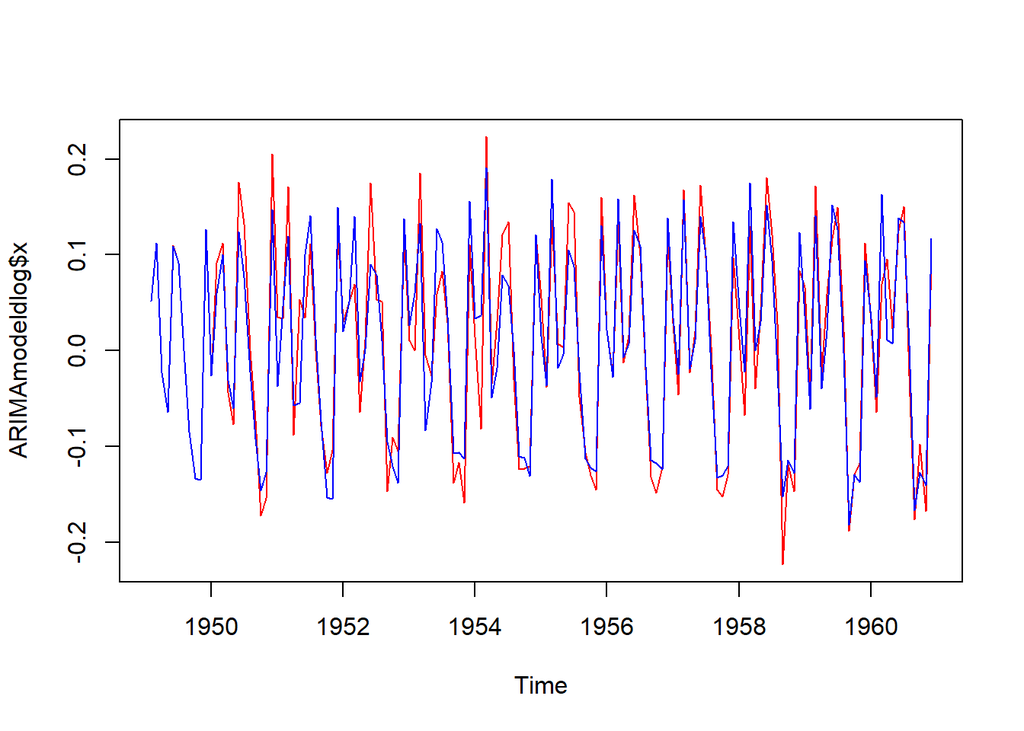

```r
plot(ARIMAmodeldlog$x, col="red")
lines(fitted(ARIMAmodeldlog), col="blue")
```

### Predicción

```r
forecast(ARIMAmodeldlog, h = 12)
```

```
         Point Forecast        Lo 80        Hi 80       Lo 95       Hi 95
Jan 1961    0.041760005 -0.005657453  0.089177463 -0.03075874  0.11427875
Feb 1961   -0.056410776 -0.107513080 -0.005308471 -0.13456501  0.02174346
Mar 1961    0.117938868  0.066836564  0.169041173  0.03978464  0.19609310
Apr 1961    0.027586656 -0.023515649  0.078688960 -0.05056758  0.10574089
May 1961    0.033255644 -0.017846661  0.084357949 -0.04489859  0.11140987
Jun 1961    0.136222424  0.085120119  0.187324729  0.05806819  0.21437665
Jul 1961    0.138515503  0.087413198  0.189617808  0.06036127  0.21666973
Aug 1961   -0.004387551 -0.055489856  0.046714754 -0.08254178  0.07376668
Sep 1961   -0.178208533 -0.229310837 -0.127106228 -0.25636276 -0.10005430
Oct 1961   -0.115689890 -0.166792195 -0.064587585 -0.19384412 -0.03753566
Nov 1961   -0.145520903 -0.196623208 -0.094418598 -0.22367513 -0.06736667
Dec 1961    0.104537303  0.053434998  0.155639608  0.02638307  0.18269153
```

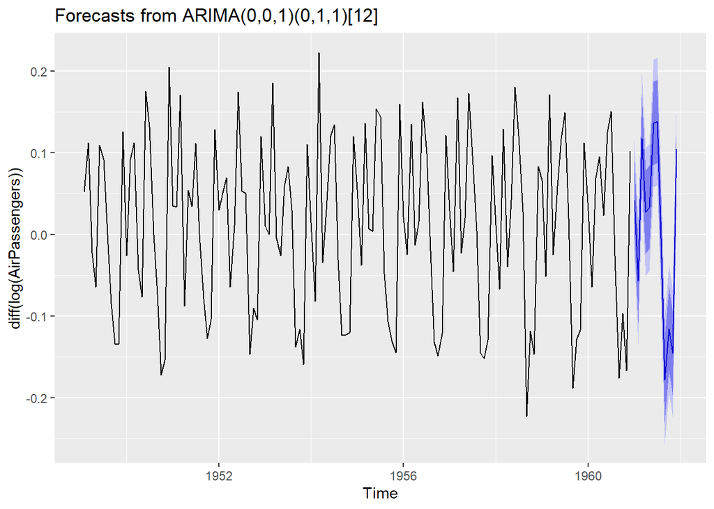

```r
autoplot(forecast(ARIMAmodeldlog, h = 12))
```

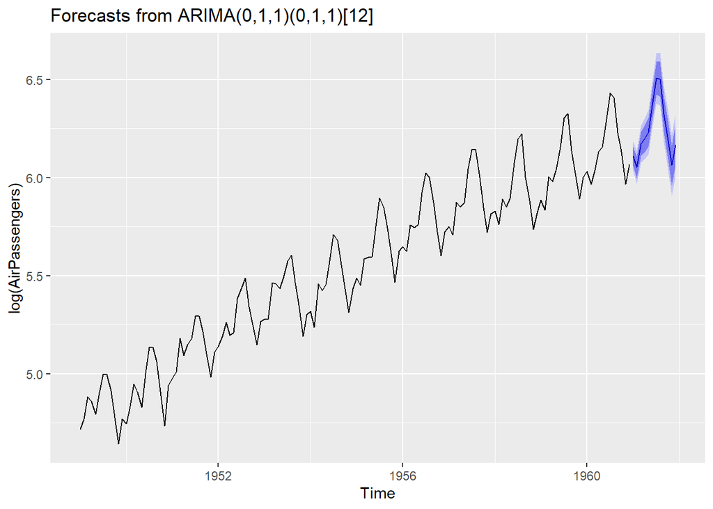

```r
autoplot(forecast(ARIMAmodel, h = 12))
```

```r
airpass<- as.data.frame(forecast(ARIMAmodel, h = 12))

exp(airpass$`Point Forecast`)
```

```
 [1] 450.4224 425.7172 479.0068 492.4045 509.0550 583.3449 670.0108 667.0776
 [9] 558.1894 497.2078 429.8720 477.2426
```

## Ejemplo 2: Calentamiento global

```r
#Datos de temperatura mundial
URL<-url("https://crudata.uea.ac.uk/cru/data/temperature/HadCRUT5.0Analysis_gl.txt")

gtemp<- read.table(URL, fill=TRUE)
View(gtemp)
## Poner los nombres de las columnas
colnames(gtemp)<-c("Año", month.abb, "Anual")
View(gtemp)

##Esta hoja de datos tienen dos tipos de fila, una para anomalía y otra de temperatura
##Solo ocupamos el primer tipo, por lo cual es siguiente comando
##elimina el en una secuencia "[-seq" segundo tipo "(2,nrow(c)," cada 2 filas "by=2"
gtemp<-gtemp[-seq(2,nrow(gtemp), by=2),]
## Poner el año como nombre de la fila
rownames(gtemp) <- gtemp[,1]
attach(gtemp)
```

Primero se deben graficar los datos para ver posibles patrones

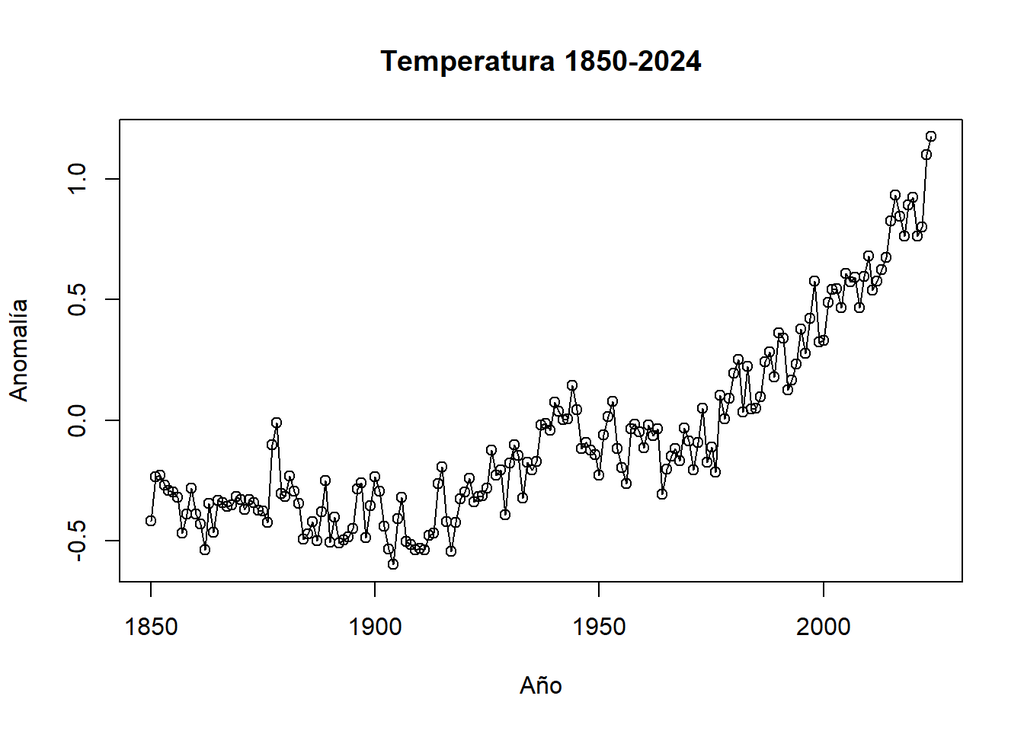

```r
#Primero se deben graficar los datos para ver posibles patrones
plot(Anual ~ Año, data = gtemp, type = "o", xlab="Año",ylab = "Anomalía",
     main = "Temperatura 1850-2024")
```

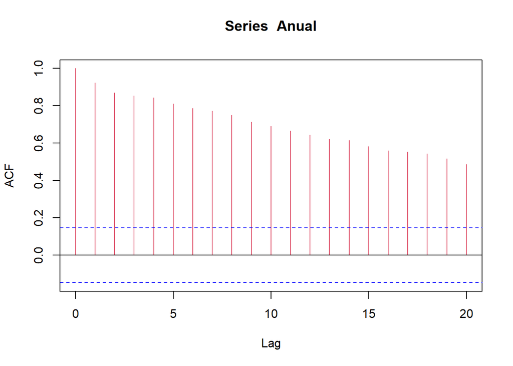

```r
#Graficar la autocorrelación
acf(Anual, col="2", lag=20)
```

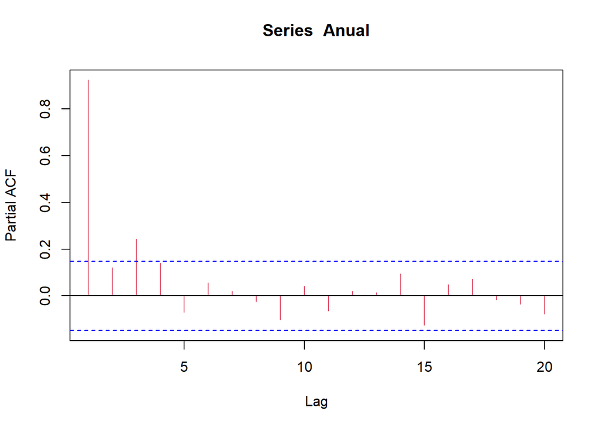

```r
#Graficar la autocorrelación parcial
pacf(Anual,col="2", lag=20)
```

Como hay confirmación de tendencia se hace la diferencia (1 lag)

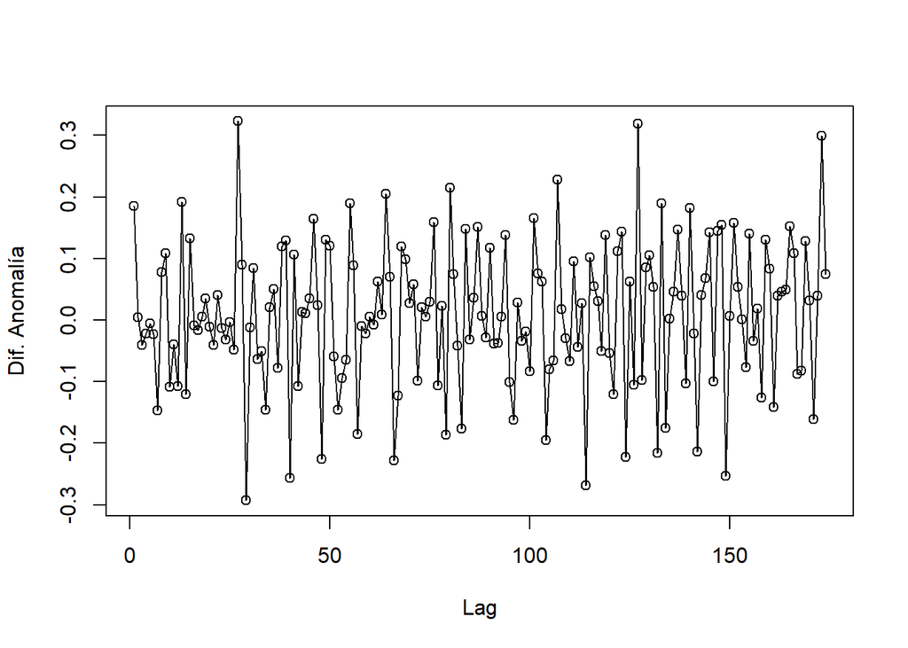

```r
plot(diff(Anual), type="o", xlab="Lag", ylab="Dif. Anomalía")
```

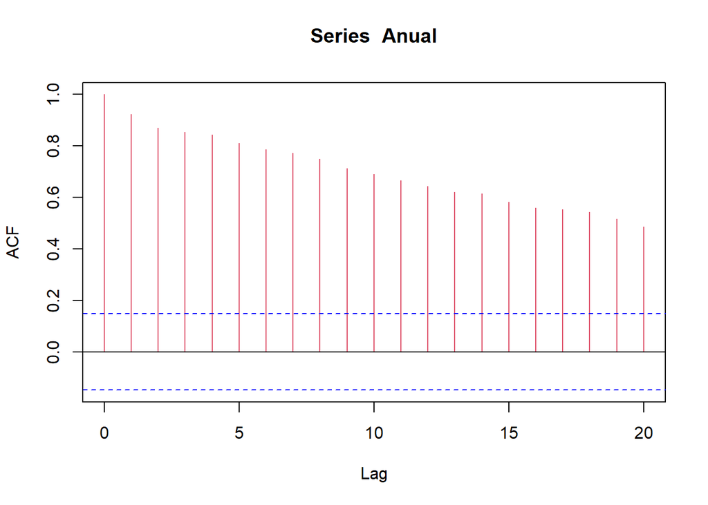

```r
#Graficar la autocorrelación
acf(Anual, col="2", lag=20)
```

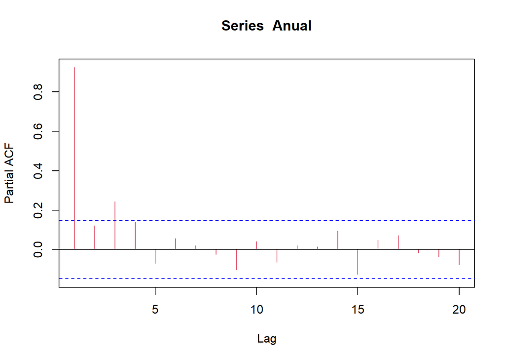

```r
#Graficar la autocorrelación parcial
pacf(Anual,col="2", lag=20)
```

```r
adf.test(diff(log(AirPassengers)), alternative="stationary")
```

```
    Augmented Dickey-Fuller Test

data:  diff(log(AirPassengers))
Dickey-Fuller = -6.4313, Lag order = 5, p-value = 0.01
alternative hypothesis: stationary
```

Corremos modelo de forma manual

```r
# de acuerdo a gráficos
ARIMAmodel1 <- arima(Anual, order=c(3,1,0))
ARIMAmodel2 <- arima(Anual, order=c(3,1,1))
# Comparador aleatorio
ARIMAmodel3 <- arima(Anual, order=c(0,1,3))

AIC <- c(ARIMAmodel1$aic, ARIMAmodel2$aic, ARIMAmodel3$aic)
Loglik<- c(ARIMAmodel1$loglik, ARIMAmodel2$loglik, ARIMAmodel3$loglik)

data.frame(Loglik, AIC)
```

```
    Loglik       AIC
1 142.4291 -276.8582
2 142.6369 -275.2738
3 140.2722 -272.5445
```

Corremos modelo de forma automática

```r
ARIMAmodel2 <- auto.arima(Anual)
ARIMAmodel2
```

```
Series: Anual
ARIMA(3,1,2) with drift

Coefficients:
          ar1      ar2      ar3     ma1      ma2   drift
      -0.7049  -0.0911  -0.3179  0.3503  -0.4863  0.0078
s.e.   0.1410   0.1836   0.0883  0.1419   0.1355  0.0032

sigma^2 = 0.01106:  log likelihood = 147.65
AIC=-281.29   AICc=-280.62   BIC=-259.18
```

### Diagnóstico del modelo

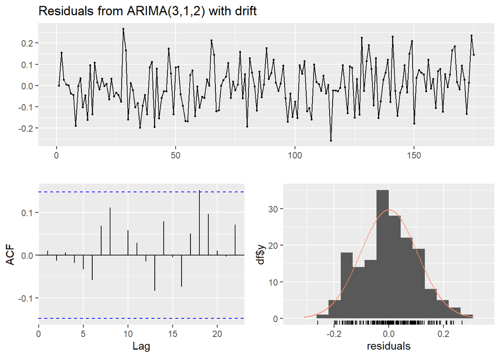

```
    Ljung-Box test

data:  Residuals from ARIMA(3,1,2) with drift
Q* = 4.7572, df = 5, p-value = 0.4462

Model df: 5.   Total lags used: 10
```

```r
checkresiduals(ARIMAmodel2)
```

### observados vs esperados

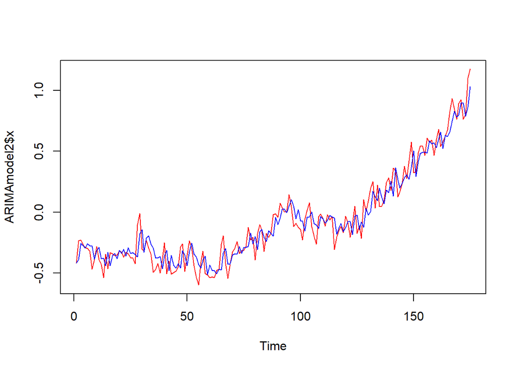

```r
plot(ARIMAmodel2$x, col="red")
lines(fitted(ARIMAmodel2), col ="blue")
```

### Predicción

```r
forecast(ARIMAmodel2, h = 12)
```

```
    Point Forecast     Lo 80    Hi 80     Lo 95    Hi 95
176      1.0349833 0.9001820 1.169785 0.8288225 1.241144
177      0.9774425 0.8170056 1.137879 0.7320755 1.222810
178      1.0233007 0.8572370 1.189364 0.7693283 1.277273
179      1.0571220 0.8873128 1.226931 0.7974212 1.316823
180      1.0637892 0.8837253 1.243853 0.7884052 1.339173
181      1.0578196 0.8688331 1.246806 0.7687897 1.346850
182      1.0670578 0.8689916 1.265124 0.7641416 1.369974
183      1.0753600 0.8709805 1.279740 0.7627885 1.387932
184      1.0869547 0.8746976 1.299212 0.7623355 1.411574
185      1.0914786 0.8727911 1.310166 0.7570249 1.425932
186      1.1009845 0.8747073 1.327262 0.7549234 1.447046
187      1.1065757 0.8742899 1.338861 0.7513253 1.461826
```

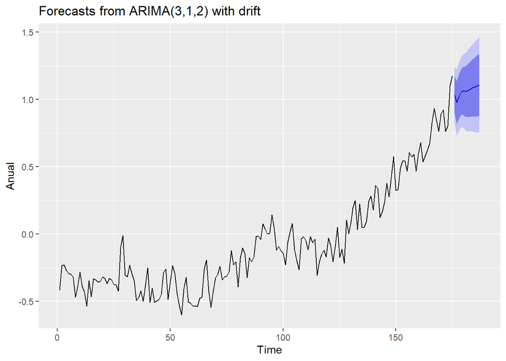

```r
autoplot(forecast(ARIMAmodel2, h = 12))
```

## Ejemplo 3: Avistamiento de tiburones

```r
# Crear la base de datos de avistamientos de tiburones martillo
tiburones_data <- data.frame(
  Año = rep(2003:2006, each = 12),
  Mes = rep(c("Jan", "Feb", "Mar", "Apr", "May", "Jun", "Jul", "Aug", "Sep", "Oct", "Nov", "Dec"), 4),
  Avistamientos = c(
    66, 35, 77, 82, 20, 101, 147, 94, 111, 99, 49, 82,
    56, 46, 22, 22, 139, 71, 142, 75, 54, 8, 38, 62,
    83, 45, 71, 84, 130, 73, 62, 94, 89, 3, 54, 26,
    22, 19, 151, 173, 172, 97, 134, 184, 193, 195, 202, 96
  )
)

# Convertir a serie temporal
martillo.ts <- ts(tiburones_data$Avistamientos, start = c(2003, 1), end = c(2006, 12), frequency = 12)

martillo.ts
```

```
     Jan Feb Mar Apr May Jun Jul Aug Sep Oct Nov Dec
2003  66  35  77  82  20 101 147  94 111  99  49  82
2004  56  46  22  22 139  71 142  75  54   8  38  62
2005  83  45  71  84 130  73  62  94  89   3  54  26
2006  22  19 151 173 172  97 134 184 193 195 202  96
```

Podemos descomponer la serie

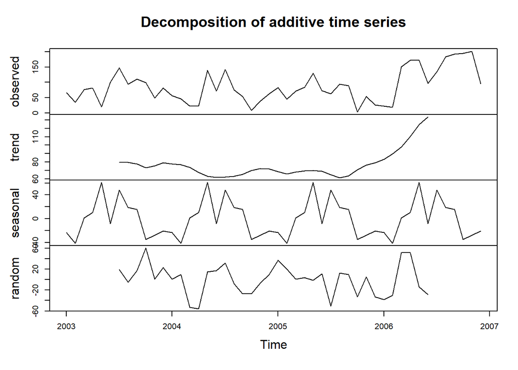

```r
library(forecast)
library(sweep)
fit_decomposed <- martillo.ts %>%
    decompose()

plot(fit_decomposed)
```

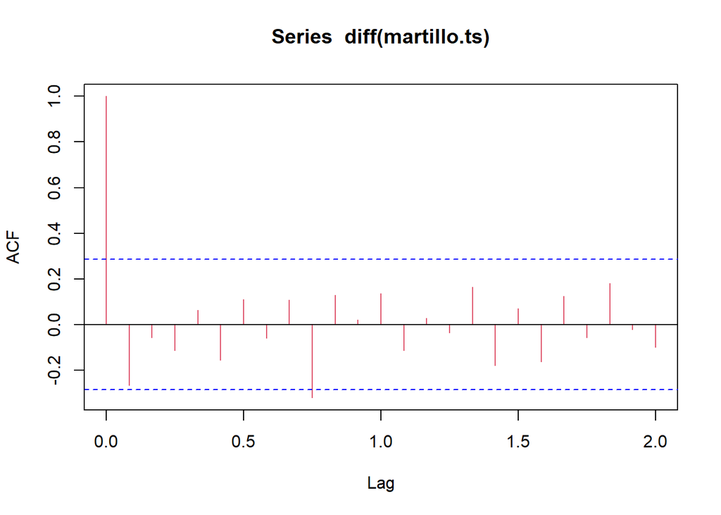

```r
acf(diff(martillo.ts), col="2", lag=24)
```

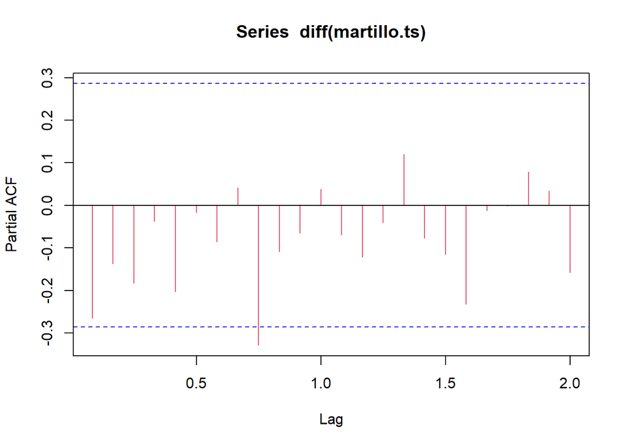

```r
pacf(diff(martillo.ts), col="2", lag=24)
```

```r
ARIMAmodel1<-auto.arima(martillo.ts)
ARIMAmodel1
```

```
Series: martillo.ts
ARIMA(0,1,1)(0,0,1)[12]

Coefficients:
          ma1    sma1
      -0.5401  0.4325
s.e.   0.1743  0.2447

sigma^2 = 1977:  log likelihood = -245.44
AIC=496.87   AICc=497.43   BIC=502.42
```

```r
ARIMAmodel2<-arima(martillo.ts, order=c(0,1,1), seasonal=c(0,0,1))
```

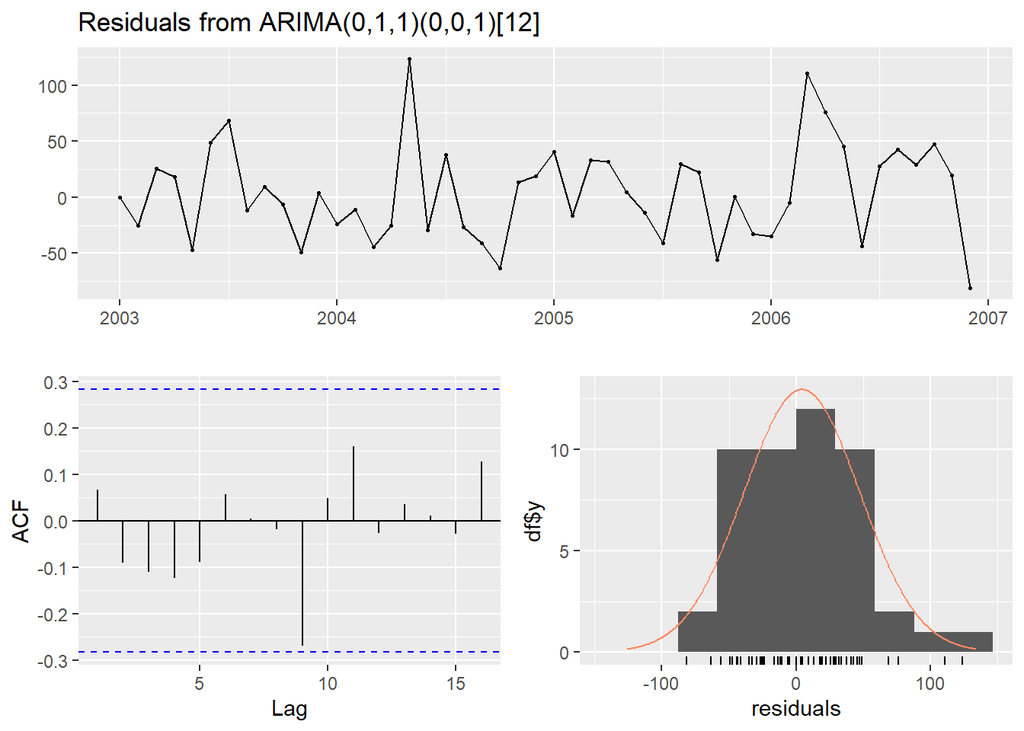

```
    Ljung-Box test

data:  Residuals from ARIMA(0,1,1)(0,0,1)[12]
Q* = 7.4314, df = 8, p-value = 0.4909

Model df: 2.   Total lags used: 10
```

```r
checkresiduals(ARIMAmodel1)
```

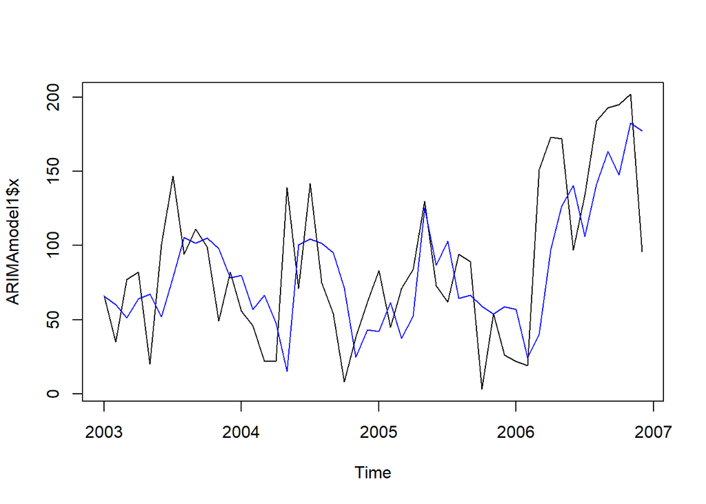

```r
plot(ARIMAmodel1$x,col="black")
lines(fitted(ARIMAmodel1), col="blue")
```

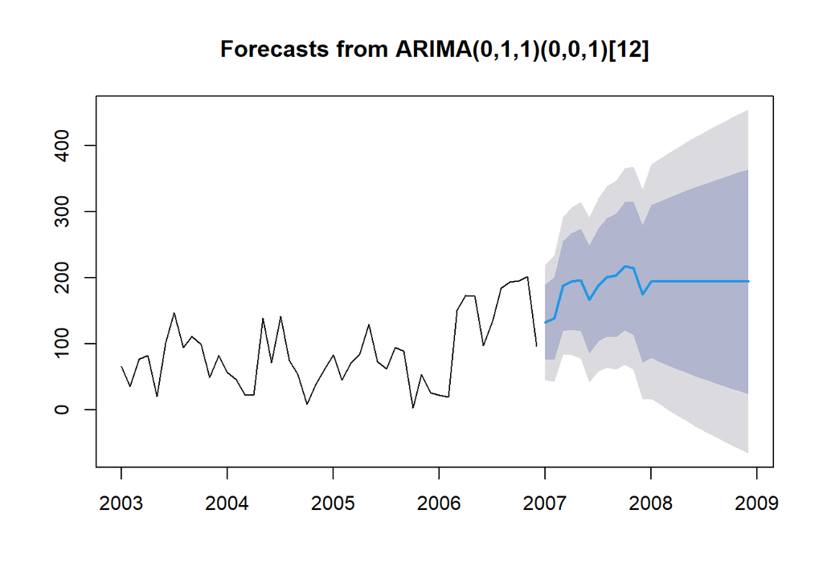

```r
plot(forecast(ARIMAmodel1))
```

# Interrupted Time Series

```r
library( "scales" )        # variable transforms, formatting tables
library( "stargazer" )     # formatting regression output
library( "dplyr" )         # data wrangling
library( "pander" )        # nice tables
#devtools::install_github( repo="OuhscBbmc/Wats")
library( "Wats" )          # time series plots
```

## Descripción general del modelo

Las series temporales interrumpidas se pueden utilizar cuando:

1. Tenemos datos sobre un resultado a lo largo del tiempo (datos longitudinales) Y
2. Queremos entender cómo y si el resultado ha cambiado después de una intervención, una política o un programa que se implementó para toda la población en un momento específico en el tiempo.

Sus datos deben incluir observaciones **antes y después** de la intervención. Cuantas más observaciones tenga de ambos lados de la intervención, más sólido será su modelo (normalmente).

Algunos ejemplos incluyen:

| **Datos** | **Pregunta de investigación** |
| --- | --- |
| Datos anuales sobre el consumo de marihuana en un estado | ¿Aumenta el consumo de marihuana después de que el estado aprueba una ley que legaliza su uso? |
| Datos mensuales de empleo en empresas locales de una ciudad | ¿Un aumento del salario mínimo afecta los niveles de empleo locales? |
| Número de libros leídos mensualmente por los estudiantes de una escuela | ¿La apertura de una nueva biblioteca dentro de la escuela afecta el número de libros leídos por los estudiantes? |

La variable dependiente en estos modelos será a veces un promedio de la población. Por ejemplo, el PIB de un país, la tasa de criminalidad de una ciudad o la puntuación media en matemáticas de una escuela.

A diferencia de la mayoría de los otros modelos de políticas que requieren muchos controles, estos modelos son útiles porque pueden generar inferencias válidas en determinadas circunstancias con solo dos variables independientes: el tiempo y la fecha de inicio del programa.

Para nuestro primer ejemplo, supongamos que tenemos datos sobre el consumo total de tabaco en un estado de EE. UU. desde un momento determinado (t0) hasta diez años después (t10). Nuestras observaciones se representan en el gráfico 1.1 que aparece a continuación. La línea sugiere una tendencia ascendente, ya que los residentes del estado consumen más tabaco con el paso del tiempo.

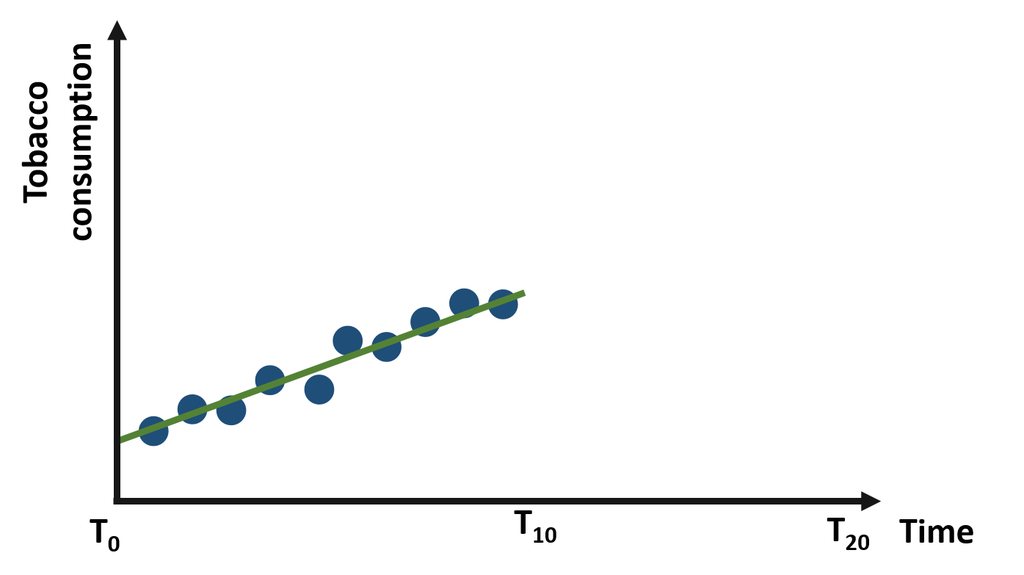

Figura 1.1: Consumo anual de tabaco desde t0 hasta t10

Imaginemos ahora que los responsables políticos deciden introducir un nuevo impuesto al tabaco al final del año t10 para reducir su consumo. ¿Cuáles son los posibles resultados de esta intervención?